# Final

Partha S Satpathy

May 15, 2017

```r
library(fma)
library(psych)
#library(lubridate)
library(party)
library(randomForest)
library(caret)
library(tseries)
#library(data.table)
library(Boruta)
library(plyr)
library(dplyr)
#library(pROC)
library(Metrics)
library(imputeTS)
library(xgboost)
library(smooth)
```

```r
library(Mcomp)
#load libraries
pkgs <- c('tidyverse', 'corrplot', 'magrittr', 'zoo', 'RColorBrewer', 'gridExtra','MASS')
invisible(lapply(pkgs, require, character.only = T))
path = 'C:/Users/parth/Desktop/Git/Projects/DengAI/Data/'
train_df <- read.csv(paste(path,'dengue_features_train.csv',sep = ""),stringsAsFactors = F)
print(c(nrow(train_df),ncol(train_df)))
```

```
## [1] 1456   24
```

```r
head(train_df)
```

```
##   city year weekofyear week_start_date   ndvi_ne   ndvi_nw   ndvi_se
## 1   sj 1990         18      1990-04-30 0.1226000 0.1037250 0.1984833
## 2   sj 1990         19      1990-05-07 0.1699000 0.1421750 0.1623571
## 3   sj 1990         20      1990-05-14 0.0322500 0.1729667 0.1572000
## 4   sj 1990         21      1990-05-21 0.1286333 0.2450667 0.2275571
## 5   sj 1990         22      1990-05-28 0.1962000 0.2622000 0.2512000
## 6   sj 1990         23      1990-06-04        NA 0.1748500 0.2543143
##     ndvi_sw precipitation_amt_mm reanalysis_air_temp_k
## 1 0.1776167                12.42              297.5729
## 2 0.1554857                22.82              298.2114
## 3 0.1708429                34.54              298.7814
## 4 0.2358857                15.36              298.9871
## 5 0.2473400                 7.52              299.5186
## 6 0.1817429                 9.58              299.6300
##   reanalysis_avg_temp_k reanalysis_dew_point_temp_k
```

[output cut: 41 more lines]

```r
test_df <- read.csv(paste(path,'dengue_features_test.csv',sep = ""),stringsAsFactors = F)
print(c(nrow(test_df),ncol(test_df)))
```

```
## [1] 416  24
```

```r
head(test_df)
```

```
##   city year weekofyear week_start_date ndvi_ne     ndvi_nw    ndvi_se
## 1   sj 2008         18      2008-04-29 -0.0189 -0.01890000 0.10272860
## 2   sj 2008         19      2008-05-06 -0.0180 -0.01240000 0.08204286
## 3   sj 2008         20      2008-05-13 -0.0015          NA 0.15108330
## 4   sj 2008         21      2008-05-20      NA -0.01986667 0.12432860
## 5   sj 2008         22      2008-05-27  0.0568  0.03983333 0.06226667
## 6   sj 2008         23      2008-06-03 -0.0440 -0.03046667 0.13200000
##      ndvi_sw precipitation_amt_mm reanalysis_air_temp_k
## 1 0.09120000                78.60              298.4929
## 2 0.07231429                12.56              298.4757
## 3 0.09152857                 3.66              299.4557
## 4 0.12568570                 0.00              299.6900
## 5 0.07591429                 0.76              299.7800
## 6 0.08352857                71.17              299.7686
##   reanalysis_avg_temp_k reanalysis_dew_point_temp_k
```

[output cut: 41 more lines]

```r
combine_df <- rbind(train_df,test_df)
print(c(nrow(combine_df),ncol(combine_df)))
```

```
## [1] 1872   24
```

```r
head(combine_df)
```

```
##   city year weekofyear week_start_date   ndvi_ne   ndvi_nw   ndvi_se
## 1   sj 1990         18      1990-04-30 0.1226000 0.1037250 0.1984833
## 2   sj 1990         19      1990-05-07 0.1699000 0.1421750 0.1623571
## 3   sj 1990         20      1990-05-14 0.0322500 0.1729667 0.1572000
## 4   sj 1990         21      1990-05-21 0.1286333 0.2450667 0.2275571
## 5   sj 1990         22      1990-05-28 0.1962000 0.2622000 0.2512000
## 6   sj 1990         23      1990-06-04        NA 0.1748500 0.2543143
##     ndvi_sw precipitation_amt_mm reanalysis_air_temp_k
## 1 0.1776167                12.42              297.5729
## 2 0.1554857                22.82              298.2114
## 3 0.1708429                34.54              298.7814
## 4 0.2358857                15.36              298.9871
## 5 0.2473400                 7.52              299.5186
## 6 0.1817429                 9.58              299.6300
##   reanalysis_avg_temp_k reanalysis_dew_point_temp_k
```

[output cut: 41 more lines]

```r
describe(combine_df)
```

```
##                                       vars    n    mean    sd  median
## city*                                    1 1872     NaN    NA      NA
## year                                     2 1872 2003.19  6.29 2004.00
## weekofyear                               3 1872   26.49 15.01   26.00
## week_start_date*                         4 1872     NaN    NA      NA
## ndvi_ne                                  5 1635    0.14  0.15    0.13
## ndvi_nw                                  6 1809    0.13  0.13    0.12
## ndvi_se                                  7 1849    0.20  0.08    0.20
## ndvi_sw                                  8 1849    0.20  0.09    0.19
## precipitation_amt_mm                     9 1857   44.11 42.07   36.64
## reanalysis_air_temp_k                   10 1860  298.73  1.39  298.62
## reanalysis_avg_temp_k                   11 1860  299.25  1.27  299.30
## reanalysis_dew_point_temp_k             12 1860  295.28  1.53  295.67
## reanalysis_max_air_temp_k               13 1860  303.47  3.21  302.60
## reanalysis_min_air_temp_k               14 1860  295.72  2.61  296.20
## reanalysis_precip_amt_kg_per_m2         15 1860   40.60 44.71   27.08
## reanalysis_relative_humidity_percent    16 1860   82.24  7.20   80.31
## reanalysis_sat_precip_amt_mm            17 1857   44.11 42.07   36.64
## reanalysis_specific_humidity_g_per_kg   18 1860   16.79  1.55   17.14
## reanalysis_tdtr_k                       19 1860    4.95  3.55    2.87
## station_avg_temp_c                      20 1817   27.23  1.28   27.43
## station_diur_temp_rng_c                 21 1817    8.00  2.21    7.20
## station_max_temp_c                      22 1849   32.47  1.95   32.80
## station_min_temp_c                      23 1849   22.16  1.61   22.20
## station_precip_mm                       24 1845   38.20 44.96   23.80
##                                       trimmed   mad     min     max  range
## city*                                     NaN    NA     Inf    -Inf   -Inf
## year                                  2003.54  7.41 1990.00 2013.00  23.00
## weekofyear                              26.49 19.27    1.00   53.00  52.00
## week_start_date*                          NaN    NA     Inf    -Inf   -Inf
## ndvi_ne                                  0.14  0.16   -0.46    0.51   0.97
## ndvi_nw                                  0.13  0.13   -0.46    0.65   1.11
## ndvi_se                                  0.20  0.07   -0.02    0.54   0.55
## ndvi_sw                                  0.20  0.08   -0.06    0.55   0.61
## precipitation_amt_mm                    38.72 42.19    0.00  390.60 390.60
## reanalysis_air_temp_k                  298.74  1.59  294.55  302.20   7.65
## reanalysis_avg_temp_k                  299.28  1.48  294.89  303.33   8.44
## reanalysis_dew_point_temp_k            295.41  1.55  289.64  298.45   8.81
## reanalysis_max_air_temp_k              303.16  2.97  297.80  314.10  16.30
## reanalysis_min_air_temp_k              295.93  2.97  286.20  299.90  13.70
```

[output cut: 20 more lines]

```
## reanalysis_air_temp_k                 -0.06    -0.73 0.03
## reanalysis_avg_temp_k                 -0.18    -0.57 0.03
## reanalysis_dew_point_temp_k           -0.70    -0.17 0.04
## reanalysis_max_air_temp_k              0.81    -0.22 0.07
## reanalysis_min_air_temp_k             -0.63    -0.32 0.06
## reanalysis_precip_amt_kg_per_m2        3.09    17.46 1.04
## reanalysis_relative_humidity_percent   0.56    -0.48 0.17
## reanalysis_sat_precip_amt_mm           1.68     6.42 0.98
## reanalysis_specific_humidity_g_per_kg -0.54    -0.53 0.04
## reanalysis_tdtr_k                      1.03    -0.32 0.08
## station_avg_temp_c                    -0.50    -0.21 0.03
## station_diur_temp_rng_c                0.82    -0.36 0.05
## station_max_temp_c                    -0.27     0.10 0.05
## station_min_temp_c                    -0.26     0.47 0.04
## station_precip_mm                      2.95    15.53 1.05
```

## The summary shows that the data has a lot of NA values. Let’s figure that out.

```r
NA_df <- is.na(combine_df)
cols <- colnames(combine_df)
#head(NA_df)
for(j in 1:ncol(NA_df)){
  print(paste(cols[j],'::',sep = ""))
  rowNA <- vector(mode="numeric", length=0)
  for(i in 1:nrow(NA_df)){
    if(isTRUE(NA_df[i,j])){
      rowNA <- c(rowNA,i)
    }
  }
  print(paste('Total null values: ',length(rowNA),sep = ""))
  print("Null values at rows:")
  print(rowNA)
}
```

```
## [1] "city::"
## [1] "Total null values: 0"
## [1] "Null values at rows:"
## numeric(0)
## [1] "year::"
## [1] "Total null values: 0"
## [1] "Null values at rows:"
## numeric(0)
## [1] "weekofyear::"
## [1] "Total null values: 0"
## [1] "Null values at rows:"
## numeric(0)
## [1] "week_start_date::"
## [1] "Total null values: 0"
## [1] "Null values at rows:"
```

[output cut: 81 more lines]

```r
rm(i)
rm(j)
```

From the above Analysis it is clear that first 4 columns: city, year, weekofyear, week_start_date do not have NAs. While rest 20 columns have NAs. Let’s first Analyse the Non-NA columns as they will be helpful in imputing the NULL values for other columns.

```r
u = unique(combine_df['city'])
print("No of Unique cities: ")
```

```
## [1] "No of Unique cities: "
```

```r
print(u)
```

```
##     city
## 1     sj
## 937   iq
```

```r
##We have two cities: sj and iq. Let's make this a factor.
combine_df$city = as.factor(combine_df$city)

##Let's check the distribution of the cities
counts <- table(combine_df$city)
print(counts)
```

```
##
##   iq   sj
##  676 1196
```

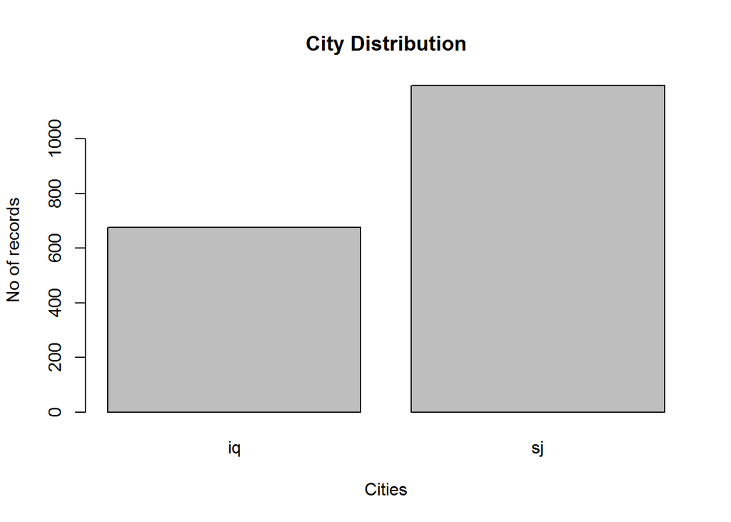

```r
barplot(counts, main="City Distribution", xlab="Cities",ylab="No of records")
```

```r
rm(counts)
rm(u)
##The above barchart shows that we have more data on sj city than iq data.
```

As we have two states, let’s analyze further for the two cities separately.

```
## [1] "city sj::No of Unique Years: "
##  [1] 1990 1991 1992 1993 1994 1995 1996 1997 1998 1999 2000 2001 2002 2003
## [15] 2004 2005 2006 2007 2008 2009 2010 2011 2012 2013
##
## 1990 1991 1992 1993 1994 1995 1996 1997 1998 1999 2000 2001 2002 2003 2004
##   35   52   52   52   52   52   52   52   52   52   52   52   52   52   52
## 2005 2006 2007 2008 2009 2010 2011 2012 2013
##   52   52   52   52   52   52   52   52   17
```

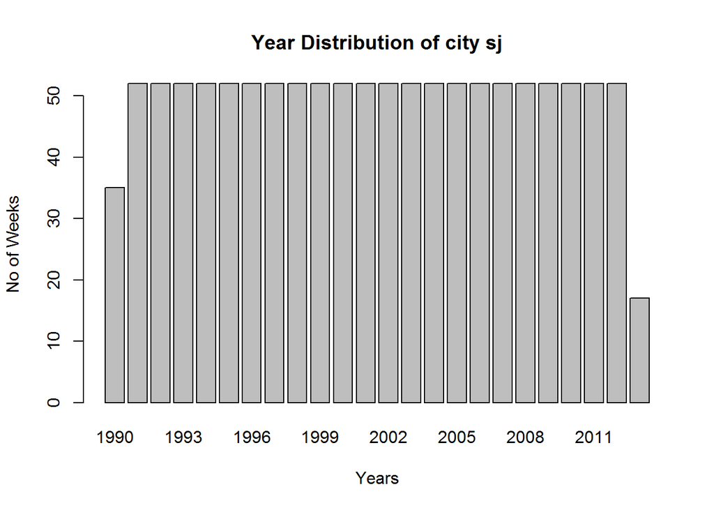

```
## [1] "city iq::No of Unique Years: "
##  [1] 2000 2001 2002 2003 2004 2005 2006 2007 2008 2009 2010 2011 2012 2013
##
## 2000 2001 2002 2003 2004 2005 2006 2007 2008 2009 2010 2011 2012 2013
##   26   52   52   52   52   52   52   52   52   52   52   52   52   26
```

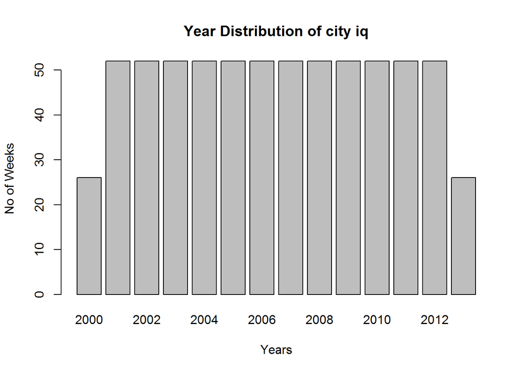

```r
analyseByYear <- function(temp_df,city){
  u = unique(temp_df$year)
  print(paste("city ",city,"::No of Unique Years: ",sep = ""))
  print(u)

  ##Let's check the distribution of the cities
  counts <- table(temp_df$year)
  print(counts)
  barplot(counts, main=paste("Year Distribution of city ",city,sep = ""), xlab="Years",ylab="No of Weeks")
}
cities = c('sj','iq')
for(i in cities){
  temp_df <- combine_df %>% filter(city==i)
  analyseByYear(temp_df,i)
}
```

```r
rm(temp_df)
rm(i)
```

So city sj has records from 1990 to 2013. For 1990 it has 35 weeks data and for 2013- 17 weeks. For all other years we have all 52 weeks data. For city iq- we have data from 2000 to 2013. 2000 has 26 and 2013 has 26 weeks. All others have 52 weeks data.

Let’s find out from which week the data starts and ends for the two cities.

```r
printWeeks <- function(ct,startYear,endYear){
  temp_df <- combine_df %>% filter(city == ct & year == startYear)
  print(paste("STarting Year Weeks for city ",ct,":",sep = ""))
  print(temp_df$weekofyear)

  temp_df <- combine_df %>% filter(city == ct & year == endYear)
  print(paste("Ending Year Weeks for city ",ct,":",sep = ""))
  print(temp_df$weekofyear)
}

printWeeks('sj',1990,2013)
```

```
## [1] "STarting Year Weeks for city sj:"
##  [1] 18 19 20 21 22 23 24 25 26 27 28 29 30 31 32 33 34 35 36 37 38 39 40
## [24] 41 42 43 44 45 46 47 48 49 50 51 52
## [1] "Ending Year Weeks for city sj:"
##  [1]  1  2  3  4  5  6  7  8  9 10 11 12 13 14 15 16 17
```

```r
printWeeks('iq',2000,2013)
```

```
## [1] "STarting Year Weeks for city iq:"
##  [1] 26 27 28 29 30 31 32 33 34 35 36 37 38 39 40 41 42 43 44 45 46 47 48
## [24] 49 50 51
## [1] "Ending Year Weeks for city iq:"
##  [1]  1  2  3  4  5  6  7  8  9 10 11 12 13 14 15 16 17 18 19 20 21 22 23
## [24] 24 25 26
```

Now, let’s start imputing NA values. We will start with ndvi_ne. We are going to use imputeTS package which automatically imputes the missing values.

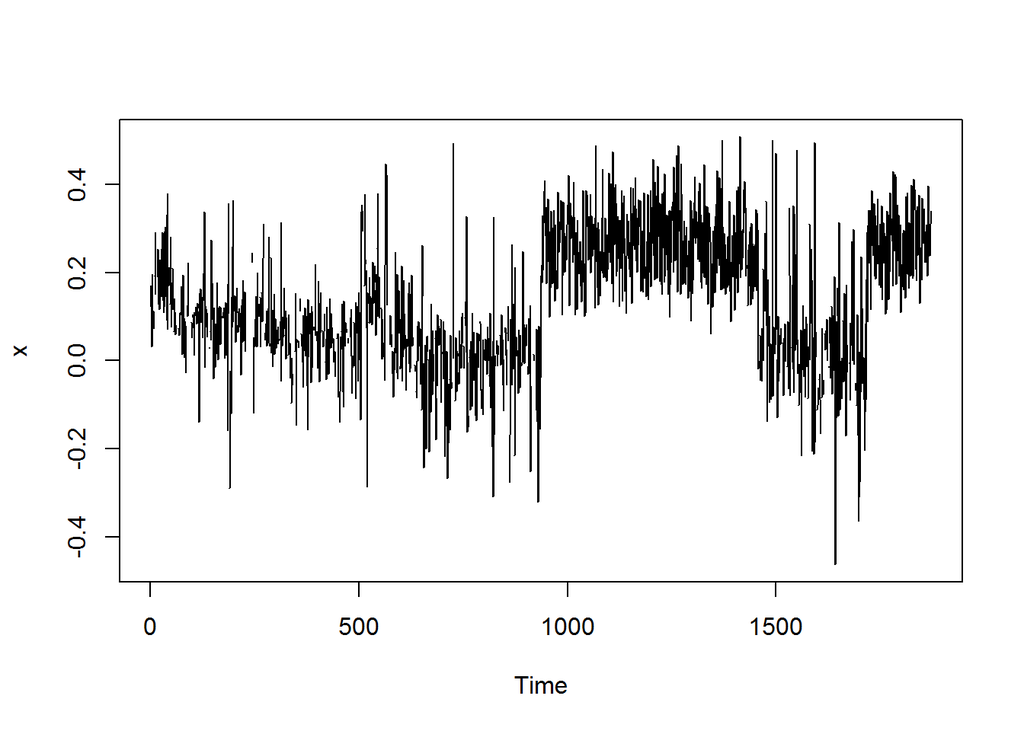

```r
x <- ts(combine_df$ndvi_ne)
plot(x)
```

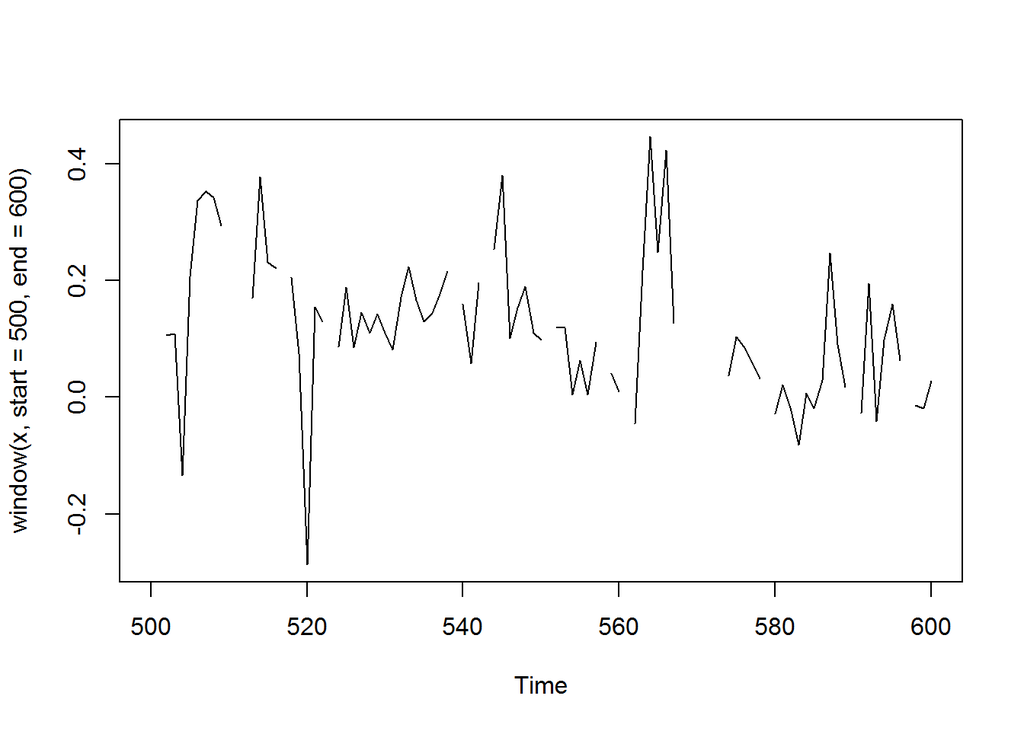

```r
##A closer look
plot(window(x,start=500,end=600))
```

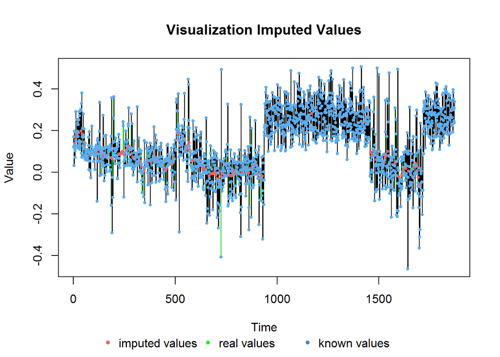

```r
#The data is not linear. There are seasonality in it.
#library(imputeTS)
imp <- na.kalman(x)
combine_df['ndvi_ne'] <- imp
plotNA.imputations(x,imp,combine_df$ndvi_ne)
```

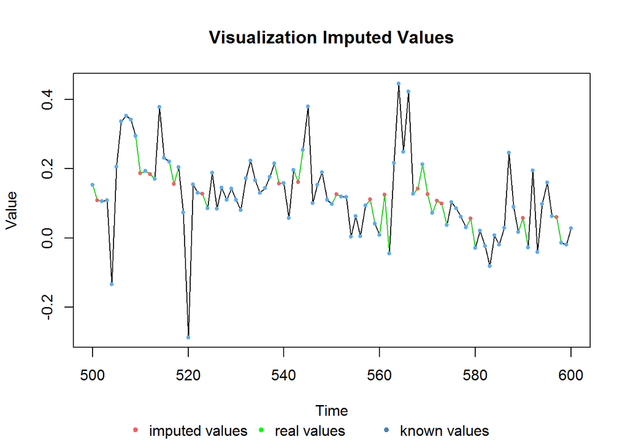

```r
#A closer look at the imputation plot
plotNA.imputations(window(x,start=500,end=600),window(imp,start=500,end=600),window(combine_df$ndvi_ne,start=500,end=600))
```

```r
rm(imp)
rm(x)
```

```r
imp <- na.kalman(combine_df[,6:24])
combine_df[,6:24] <- imp

sum(is.na(combine_df)) ## Value 0 shows no NA values
```

```
## [1] 0
```

```r
rm(imp)
```

```r
train_label_df <- read.csv(paste(path,'dengue_labels_train.csv',sep = ""),stringsAsFactors = F)
test_label_df <- read.csv(paste(path,'submission_format.csv',sep = ""),stringsAsFactors = F)
combine_label_df <- rbind(train_label_df,test_label_df)
combine_df$total_cases <- combine_label_df$total_cases

train_data_sj <- combine_df[1:1456,] %>% filter(city=='sj')
train_data_iq <- combine_df[1:1456,] %>% filter(city=='iq')

test_data_sj <- combine_df[1457:1872,] %>% filter(city=='sj')
test_data_iq <- combine_df[1457:1872,] %>% filter(city=='iq')
```

Let’s find the most important variable for the modelling We will use the Boruta package for this.

## For city SJ

```r
set.seed(13)
bor.results <- Boruta(train_data_sj[,-c(1,4,25)],train_data_sj$total_cases,maxRuns=101,doTrace=0)
bor.results$finalDecision
```

```
##                                  year
##                             Confirmed
##                            weekofyear
##                             Confirmed
##                               ndvi_ne
##                             Confirmed
##                               ndvi_nw
##                             Confirmed
##                               ndvi_se
##                             Confirmed
##                               ndvi_sw
##                             Confirmed
##                  precipitation_amt_mm
##                             Confirmed
##                 reanalysis_air_temp_k
##                             Confirmed
##                 reanalysis_avg_temp_k
##                             Confirmed
##           reanalysis_dew_point_temp_k
##                             Confirmed
##             reanalysis_max_air_temp_k
##                             Confirmed
##             reanalysis_min_air_temp_k
##                             Confirmed
##       reanalysis_precip_amt_kg_per_m2
##                             Confirmed
##  reanalysis_relative_humidity_percent
##                             Confirmed
##          reanalysis_sat_precip_amt_mm
##                             Tentative
## reanalysis_specific_humidity_g_per_kg
##                             Confirmed
##                     reanalysis_tdtr_k
##                             Tentative
##                    station_avg_temp_c
##                             Confirmed
##               station_diur_temp_rng_c
##                             Tentative
##                    station_max_temp_c
##                             Confirmed
##                    station_min_temp_c
##                             Confirmed
##                     station_precip_mm
##                             Confirmed
## Levels: Tentative Confirmed Rejected
```

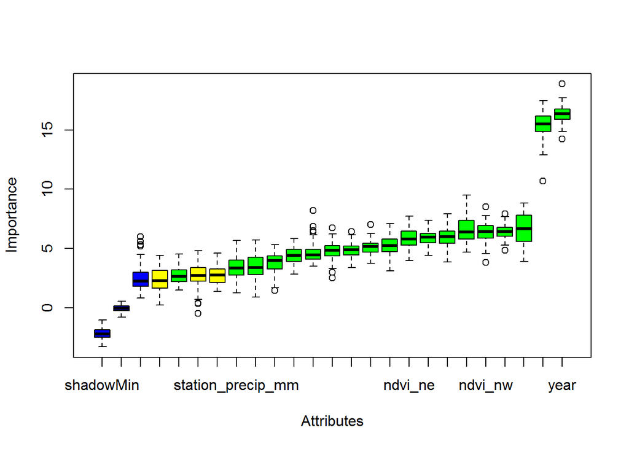

```r
plot(bor.results)
```

Segregate the variables as per their importance

```r
CONFIRMED_ATTR_SJ <- c('year','weekofyear','ndvi_nw','ndvi_ne','ndvi_sw','ndvi_se','precipitation_amt_mm','reanalysis_air_temp_k',
                    'reanalysis_avg_temp_k','reanalysis_dew_point_temp_k','reanalysis_max_air_temp_k','reanalysis_min_air_temp_k',
                    'reanalysis_precip_amt_kg_per_m2','reanalysis_relative_humidity_percent','reanalysis_specific_humidity_g_per_kg',
                    'station_avg_temp_c','station_max_temp_c','station_min_temp_c','station_precip_mm')

TENTATIVE_ATTR_SJ <- c('reanalysis_tdtr_k','reanalysis_sat_precip_amt_mm','station_diur_temp_rng_c')

PREDICTOR_ATTR_SJ <- c(CONFIRMED_ATTR_SJ,TENTATIVE_ATTR_SJ)

# create folds for training
set.seed(13)
data_folds_sj <- createFolds(train_data_sj$total_case, k=5)
```

```r
set.seed(13)
bor.results <- Boruta(train_data_iq[,-c(1,4,25)],train_data_iq$total_cases,maxRuns=101,doTrace=0)
bor.results$finalDecision
```

```
##                                  year
##                             Confirmed
##                            weekofyear
##                             Confirmed
##                               ndvi_ne
##                              Rejected
##                               ndvi_nw
##                              Rejected
##                               ndvi_se
##                              Rejected
##                               ndvi_sw
##                              Rejected
##                  precipitation_amt_mm
##                             Tentative
##                 reanalysis_air_temp_k
##                             Confirmed
##                 reanalysis_avg_temp_k
##                             Confirmed
##           reanalysis_dew_point_temp_k
##                             Confirmed
##             reanalysis_max_air_temp_k
##                             Tentative
##             reanalysis_min_air_temp_k
##                             Confirmed
##       reanalysis_precip_amt_kg_per_m2
##                             Confirmed
##  reanalysis_relative_humidity_percent
##                             Confirmed
##          reanalysis_sat_precip_amt_mm
##                             Tentative
## reanalysis_specific_humidity_g_per_kg
##                             Confirmed
##                     reanalysis_tdtr_k
##                             Confirmed
##                    station_avg_temp_c
##                             Confirmed
##               station_diur_temp_rng_c
##                             Tentative
##                    station_max_temp_c
##                             Confirmed
##                    station_min_temp_c
##                             Tentative
##                     station_precip_mm
##                              Rejected
## Levels: Tentative Confirmed Rejected
```

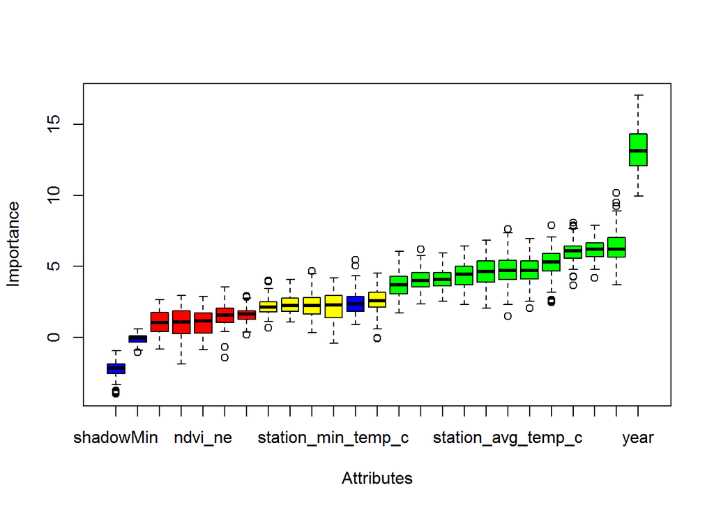

```r
plot(bor.results)
```

```r
CONFIRMED_ATTR_IQ <- c('year','weekofyear','reanalysis_air_temp_k',
                    'reanalysis_avg_temp_k','reanalysis_dew_point_temp_k','reanalysis_min_air_temp_k','reanalysis_tdtr_k',
                    'reanalysis_precip_amt_kg_per_m2','reanalysis_relative_humidity_percent','reanalysis_specific_humidity_g_per_kg',
                    'station_avg_temp_c','station_max_temp_c')

TENTATIVE_ATTR_IQ <- c('precipitation_amt_mm','reanalysis_max_air_temp_k','reanalysis_sat_precip_amt_mm','station_diur_temp_rng_c','station_min_temp_c')
REJECTED_ATTR_IQ <- c('ndvi_nw','ndvi_ne','ndvi_sw','ndvi_se','station_precip_mm')


PREDICTOR_ATTR_IQ <- c(CONFIRMED_ATTR_IQ,TENTATIVE_ATTR_IQ,REJECTED_ATTR_IQ)

# create folds for training
set.seed(13)
data_folds_iq <- createFolds(train_data_iq$total_cases, k=5)
```

Once we have found every important features, next we will try to use model For modelling we are going to use, gbm and xgboost. Both of these models are present in CARAT. So we will pre-process the data as per cARAT package. We will add a new column- ID which is just a number to the row

```r
train_data_sj$Id <- seq.int(nrow(train_data_sj))
train_data_iq$Id <- seq.int(nrow(train_data_iq))
test_data_sj$Id <- seq.int(nrow(test_data_sj))+936
test_data_iq$Id <- seq.int(nrow(test_data_iq))+520
```

```r
# Feature Set 1 - Boruta Confirmed and tentative Attributes
prepL0FeatureSet1_sj <- function(df) {

    id <- df$Id
    #print(head(id))
    if (class(df$total_cases) != "NULL") {
        y <- df$total_cases
    } else {
        y <- NULL
    }

    predictor_vars <- c(CONFIRMED_ATTR_SJ,TENTATIVE_ATTR_SJ)

    predictors <- df[predictor_vars]

    return(list(id=id,y=y,predictors=predictors))
}

L0FeatureSet1_sj <- list(train=prepL0FeatureSet1_sj(train_data_sj),test=prepL0FeatureSet1_sj(test_data_sj))
#print(head(L0FeatureSet1_sj$train$Id))

prepL0FeatureSet1_iq <- function(df) {

    id <- df$Id
    #print(head(id))
    if (class(df$total_cases) != "NULL") {
        y <- df$total_cases
    } else {
        y <- NULL
    }

    predictor_vars <- c(CONFIRMED_ATTR_IQ,TENTATIVE_ATTR_IQ)

    predictors <- df[predictor_vars]

    return(list(id=id,y=y,predictors=predictors))
}

L0FeatureSet1_iq <- list(train=prepL0FeatureSet1_iq(train_data_iq),test=prepL0FeatureSet1_iq(test_data_iq))
```

Following is the common training function that we will use to train our model.

```r
#library(Metrics)
#train model on one data fold
trainOneFold <- function(this_fold,feature_set) {
    # get fold specific cv data
    #print('Inside trainOneFold')
    cv.data <- list()
    cv.data$predictors <- feature_set$train$predictors[this_fold,]
    cv.data$ID <- feature_set$train$id[this_fold]
    cv.data$y <- feature_set$train$y[this_fold]

    #print('Crossed CV')
    # get training data for specific fold
    train.data <- list()
    train.data$predictors <- feature_set$train$predictors[-this_fold,]
    train.data$y <- feature_set$train$y[-this_fold]
    #print('Crossed train')
    #print(head(train.data$y))

    set.seed(825)
    fitted_mdl <- do.call(train,
                          c(list(x=train.data$predictors,y=train.data$y),
                        CARET.TRAIN.PARMS,
                        MODEL.SPECIFIC.PARMS,
                        CARET.TRAIN.OTHER.PARMS))

    yhat <- predict(fitted_mdl,newdata = cv.data$predictors,type = "raw")

    score <- rmse(cv.data$y,yhat)

    ans <- list(fitted_mdl=fitted_mdl,
                score=score,
                predictions=data.frame(ID=cv.data$ID,yhat=yhat,y=cv.data$y))

    return(ans)

}

# make prediction from a model fitted to one fold
makeOneFoldTestPrediction <- function(this_fold,feature_set) {
    fitted_mdl <- this_fold$fitted_mdl

    yhat <- predict(fitted_mdl,newdata = feature_set$test$predictors,type = "raw")

    return(yhat)
}
```

The below section will do the followinf tasks: 1. Define the basic parameters of gbm model 2. Tune the parametrs 3. Train the models for the two cities separately 4. Show the RMSE calted error for teh model

```r
# set caret training parameters
CARET.TRAIN.PARMS <- list(method="gbm")

CARET.TUNE.GRID <-  expand.grid(n.trees=100,
                                interaction.depth=10,
                                shrinkage=0.1,
                                n.minobsinnode=10)

MODEL.SPECIFIC.PARMS <- list(verbose=0) #NULL # Other model specific parameters

# model specific training parameter
CARET.TRAIN.CTRL <- trainControl(method="none",
                                 verboseIter=FALSE,
                                 classProbs=FALSE)

CARET.TRAIN.OTHER.PARMS <- list(trControl=CARET.TRAIN.CTRL,
                           tuneGrid=CARET.TUNE.GRID,
                           metric="RMSE")

# generate features for Level 1
gbm_set_sj <- llply(data_folds_sj,trainOneFold,L0FeatureSet1_sj)
gbm_set_iq <- llply(data_folds_iq,trainOneFold,L0FeatureSet1_iq)
# final model fit
gbm_mdl_sj <- do.call(train,
                 c(list(x=L0FeatureSet1_sj$train$predictors,y=L0FeatureSet1_sj$train$y),
                 CARET.TRAIN.PARMS,
                 MODEL.SPECIFIC.PARMS,
                 CARET.TRAIN.OTHER.PARMS))

# CV Error Estimate
cv_y <- do.call(c,lapply(gbm_set_sj,function(x){x$predictions$y}))
cv_yhat <- do.call(c,lapply(gbm_set_sj,function(x){x$predictions$yhat}))
rmse(cv_y,cv_yhat)
```

```
## [1] 30.00258
```

```r
cat("Average CV rmse for sj:",mean(do.call(c,lapply(gbm_set_sj,function(x){x$score}))))
```

```
## Average CV rmse for sj: 29.92256
```

```r
print('')
```

```
## [1] ""
```

```r
print('###############################################################')
```

```
## [1] "###############################################################"
```

```r
print('city iq:')
```

```
## [1] "city iq:"
```

```r
# final model fit
gbm_mdl_iq <- do.call(train,
                 c(list(x=L0FeatureSet1_iq$train$predictors,y=L0FeatureSet1_iq$train$y),
                 CARET.TRAIN.PARMS,
                 MODEL.SPECIFIC.PARMS,
                 CARET.TRAIN.OTHER.PARMS))

# CV Error Estimate
cv_y <- do.call(c,lapply(gbm_set_iq,function(x){x$predictions$y}))
cv_yhat <- do.call(c,lapply(gbm_set_iq,function(x){x$predictions$yhat}))
rmse(cv_y,cv_yhat)
```

```
## [1] 9.299699
```

```r
cat("Average CV rmse for iq:",mean(do.call(c,lapply(gbm_set_iq,function(x){x$score}))))
```

```
## Average CV rmse for iq: 8.928064
```

```r
test_gbm_yhat_sj <- round(predict(gbm_mdl_sj,newdata = L0FeatureSet1_sj$test$predictors,type = "raw"))
test_gbm_yhat_iq <- round(predict(gbm_mdl_iq,newdata = L0FeatureSet1_iq$test$predictors,type = "raw"))
test_gbm_yhat <- c(test_gbm_yhat_sj,test_gbm_yhat_iq)
submission <- read.csv(paste(path,'submission_format.csv',sep = ""),stringsAsFactors = F)
submission$total_cases <- test_gbm_yhat
head(submission)
```

```
##   city year weekofyear total_cases
## 1   sj 2008         18           7
## 2   sj 2008         19           4
## 3   sj 2008         20          10
## 4   sj 2008         21          20
## 5   sj 2008         22          17
## 6   sj 2008         23          11
```

```r
write.csv(submission,paste(path,'final_gbm_1.csv',sep = ""),row.names=F,quote = F)
```

The next model we are going to use is - “XGBoost”. This model needs data in matrix form. So we will change our pre-processing model

```r
# Feature Set 2 (xgboost) - Boruta Confirmed Attributes
prepL0FeatureSet2_sj <- function(df) {
    id <- df$Id
    #print(head(id))
    if (class(df$total_cases) != "NULL") {
        y <- df$total_cases
    } else {
        y <- NULL
    }

    predictor_vars <- c(CONFIRMED_ATTR_SJ,TENTATIVE_ATTR_SJ)

    predictors <- df[predictor_vars]
    return(list(id=id,y=y,predictors=as.matrix(predictors)))
}

L0FeatureSet2_sj <- list(train=prepL0FeatureSet2_sj(train_data_sj),test=prepL0FeatureSet2_sj(test_data_sj))
#print(head(L0FeatureSet1_sj$train$Id))

prepL0FeatureSet2_iq <- function(df) {

    id <- df$Id
    #print(head(id))
    if (class(df$total_cases) != "NULL") {
        y <- df$total_cases
    } else {
        y <- NULL
    }

    predictor_vars <- c(CONFIRMED_ATTR_IQ,TENTATIVE_ATTR_IQ)

    predictors <- df[predictor_vars]

    return(list(id=id,y=y,predictors=as.matrix(predictors)))
}

L0FeatureSet2_iq <- list(train=prepL0FeatureSet2_iq(train_data_iq),test=prepL0FeatureSet2_iq(test_data_iq))
```

Here again we will do the same thing as we did for gbm model.

```r
# set caret training parameters
CARET.TRAIN.PARMS <- list(method="xgbTree")

CARET.TUNE.GRID <-  expand.grid(nrounds=800,
                                max_depth=10,
                                eta=0.03,
                                gamma=0.1,
                                colsample_bytree=0.4,
                                min_child_weight=1,
                                subsample = 1)

MODEL.SPECIFIC.PARMS <- list(verbose=0) #NULL # Other model specific parameters

# model specific training parameter
CARET.TRAIN.CTRL <- trainControl(method="none",
                                 verboseIter=FALSE,
                                 classProbs=FALSE)

CARET.TRAIN.OTHER.PARMS <- list(trControl=CARET.TRAIN.CTRL,
                           tuneGrid=CARET.TUNE.GRID,
                           metric="RMSE")

# generate Level 1 features
xgb_set_sj <- llply(data_folds_sj,trainOneFold,L0FeatureSet2_sj)
xgb_set_iq <- llply(data_folds_iq,trainOneFold,L0FeatureSet2_iq)

# final model fit: city sj
xgb_mdl_sj <- do.call(train,
                 c(list(x=L0FeatureSet2_sj$train$predictors,y=L0FeatureSet2_sj$train$y),
                 CARET.TRAIN.PARMS,
                 MODEL.SPECIFIC.PARMS,
                 CARET.TRAIN.OTHER.PARMS))

# CV Error Estimate
cv_y <- do.call(c,lapply(xgb_set_sj,function(x){x$predictions$y}))
cv_yhat <- do.call(c,lapply(xgb_set_sj,function(x){x$predictions$yhat}))
rmse(cv_y,cv_yhat)
```

```
## [1] 28.66948
```

```r
# final model fit : city iq
xgb_mdl_iq <- do.call(train,
                 c(list(x=L0FeatureSet2_iq$train$predictors,y=L0FeatureSet2_iq$train$y),
                 CARET.TRAIN.PARMS,
                 MODEL.SPECIFIC.PARMS,
                 CARET.TRAIN.OTHER.PARMS))

# CV Error Estimate
cv_y <- do.call(c,lapply(xgb_set_iq,function(x){x$predictions$y}))
cv_yhat <- do.call(c,lapply(xgb_set_iq,function(x){x$predictions$yhat}))
rmse(cv_y,cv_yhat)
```

```
## [1] 9.521879
```

```r
test_xgb_yhat_sj <- round(predict(xgb_mdl_sj,newdata = L0FeatureSet2_sj$test$predictors,type = "raw"))
test_xgb_yhat_iq <- round(predict(xgb_mdl_iq,newdata = L0FeatureSet2_iq$test$predictors,type = "raw"))
test_xgb_yhat <- c(test_xgb_yhat_sj,test_xgb_yhat_iq)

##Lets check how this model looks like in plot
plot(train_data_sj$total_cases,type="l",xlim=c(100,300))
```

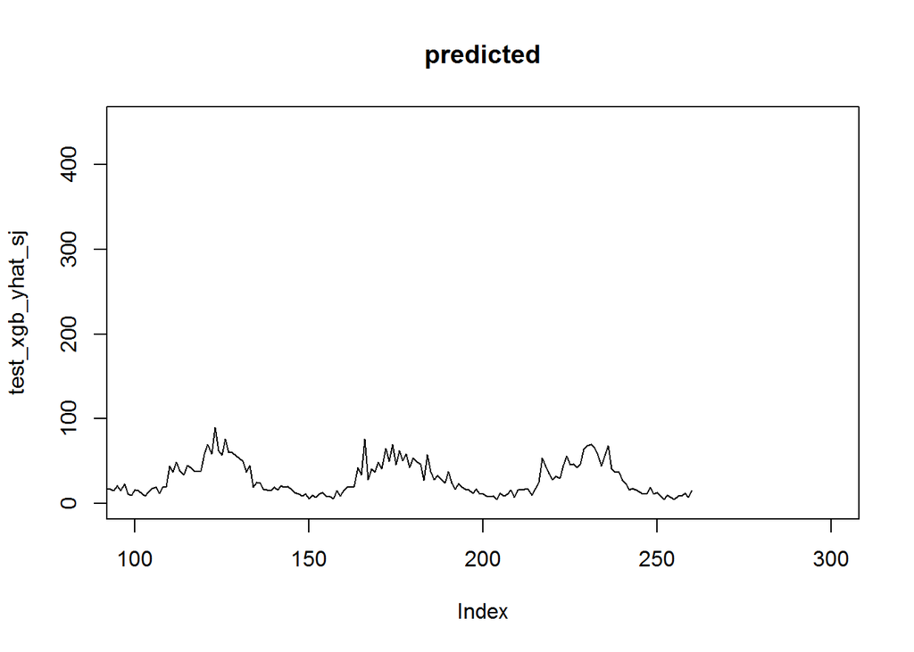

```r
plot(test_xgb_yhat_sj,type="l",ylim=c(0,450),xlim=c(100,300),main='predicted')
```

```r
fit_sj <- sma(test_xgb_yhat_sj)
```

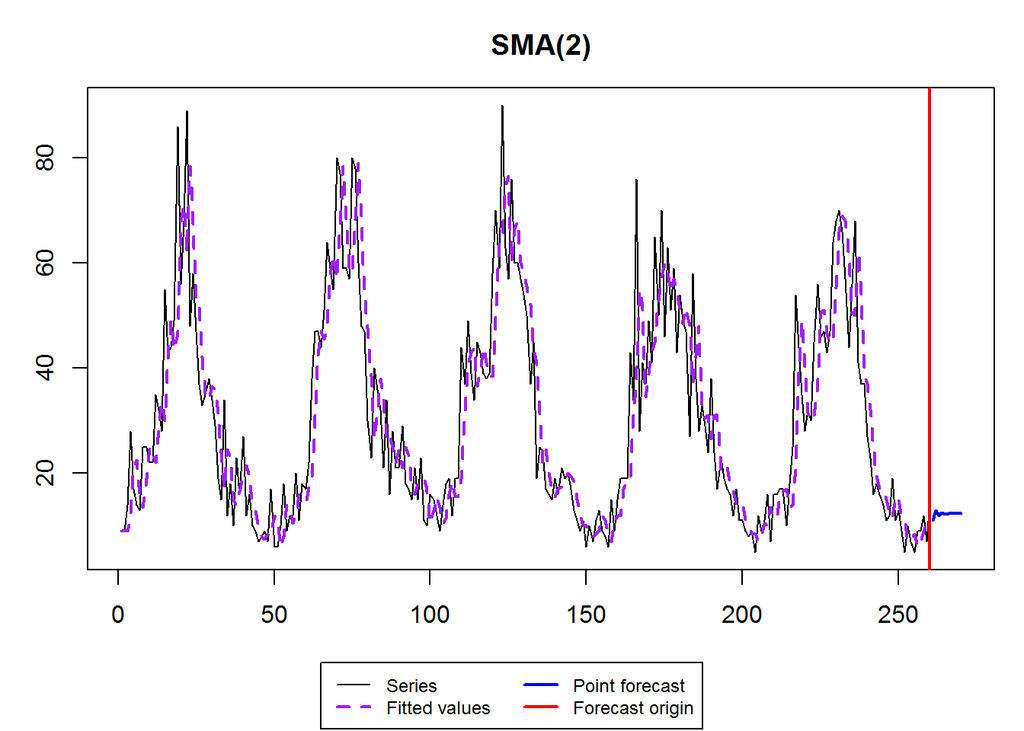

```r
fit_iq <- sma(test_xgb_yhat_iq)
```

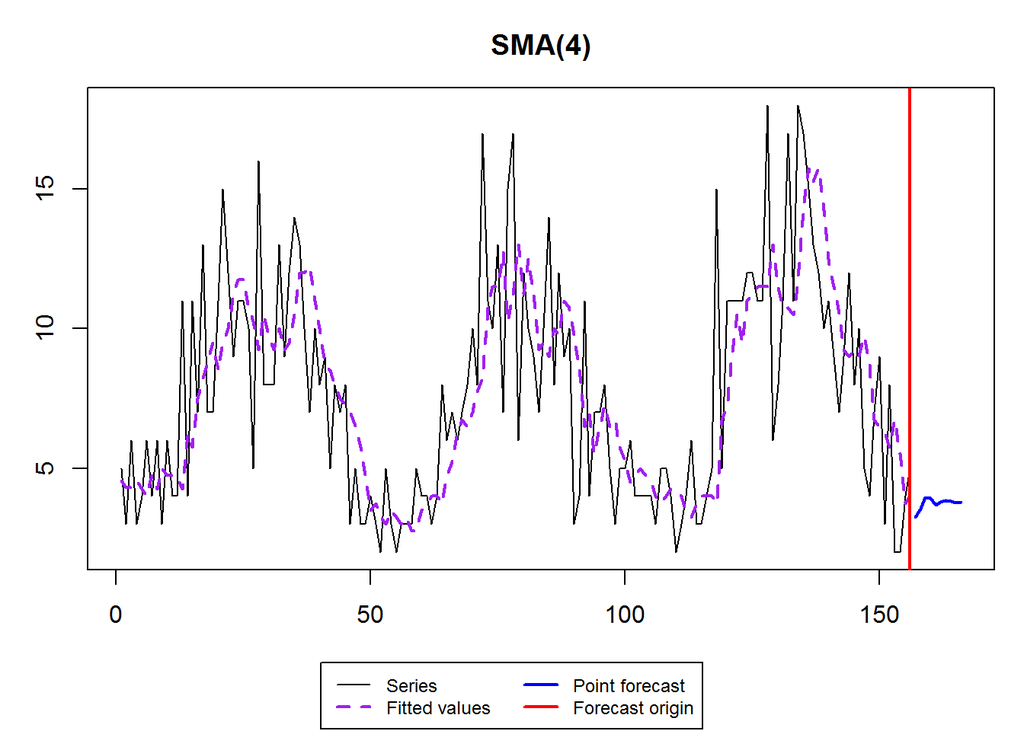

```r
test_xgb_yhat_sma <- c(as.numeric(fit_sj$fitted),as.numeric(fit_iq$fitted))
plot(train_data_sj$total_cases,type="l",xlim=c(100,300))
```

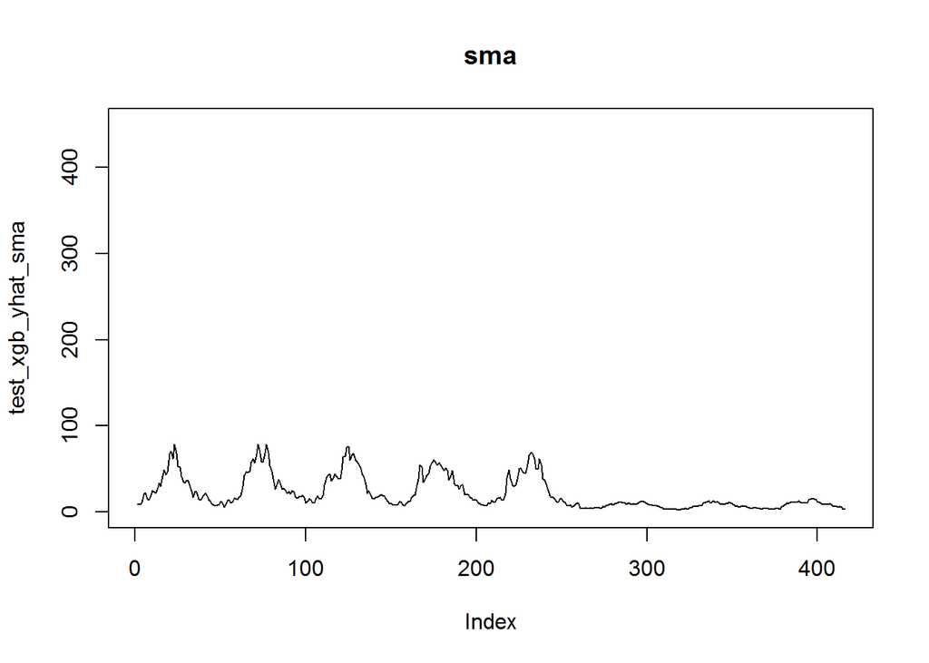

```r
plot(test_xgb_yhat_sma,type="l",ylim=c(0,450),main="sma")
```

```r
submission <- read.csv(paste(path,'submission_format.csv',sep = ""),stringsAsFactors = F)
submission$total_cases <- round(test_xgb_yhat_sma)
head(submission)
```

```
##   city year weekofyear total_cases
## 1   sj 2008         18           9
## 2   sj 2008         19           9
## 3   sj 2008         20           9
## 4   sj 2008         21          12
## 5   sj 2008         22          21
## 6   sj 2008         23          22
```

```r
write.csv(submission,paste(path,'final_xgboost_1.csv',sep = ""),row.names=F,quote = F)
```

Let’s smooth the gbm model too

```r
plot(train_data_sj$total_cases,type="l",xlim=c(100,300))
```

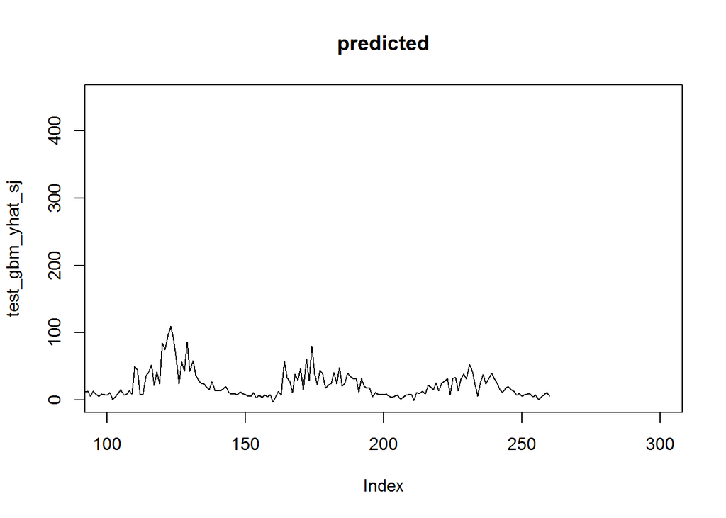

```r
plot(test_gbm_yhat_sj,type="l",ylim=c(0,450),xlim=c(100,300),main='predicted')
```

```r
fit_sj <- sma(test_gbm_yhat_sj)
```

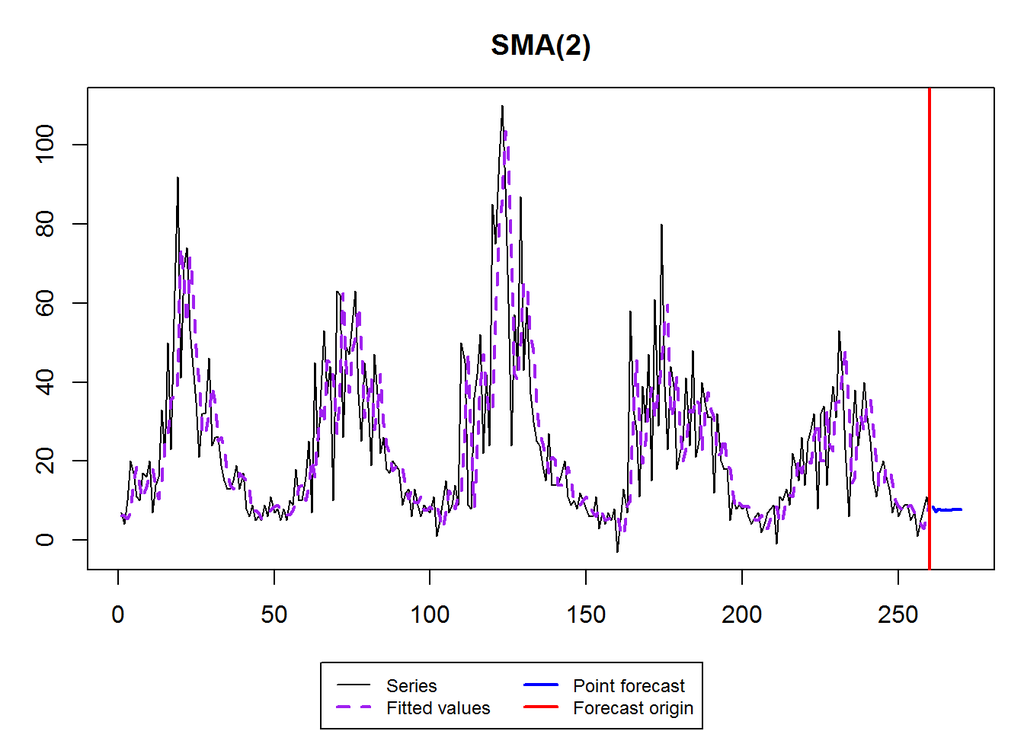

```r
fit_iq <- sma(test_gbm_yhat_iq)
```

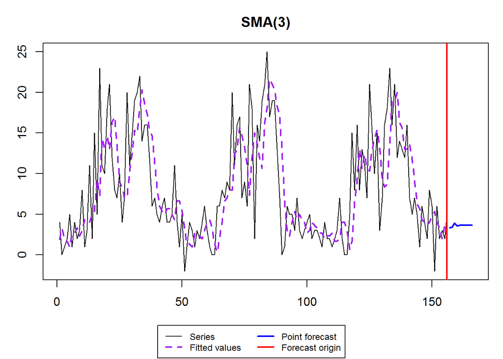

```r
test_gbm_yhat_sma <- c(as.numeric(fit_sj$fitted),as.numeric(fit_iq$fitted))
plot(train_data_sj$total_cases,type="l",xlim=c(100,300))
```

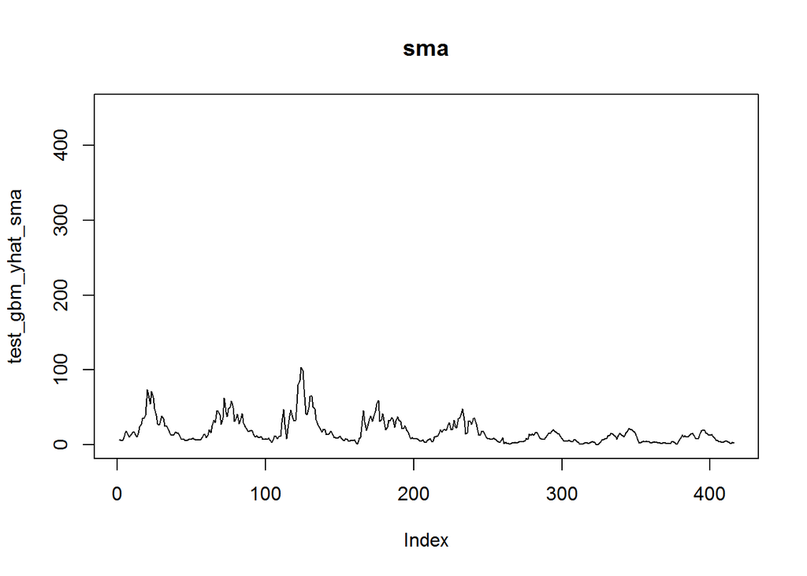

```r
plot(test_gbm_yhat_sma,type="l",ylim=c(0,450),main="sma")
```

```r
submission <- read.csv(paste(path,'submission_format.csv',sep = ""),stringsAsFactors = F)
submission$total_cases <- round(test_gbm_yhat_sma)
head(submission)
```

```
##   city year weekofyear total_cases
## 1   sj 2008         18           6
## 2   sj 2008         19           6
## 3   sj 2008         20           6
## 4   sj 2008         21           7
## 5   sj 2008         22          15
## 6   sj 2008         23          18
```

```r
write.csv(submission,paste(path,'final_gbm_2.csv',sep = ""),row.names=F,quote = F)
```

GBM with smoothing was not an improvement. But xgboost with Moving average smoothing was an improvement- MAE: 25.73

For the last part let’s try the xgboost model directly from xgboost package

```r
library(xgboost)

sj_dtrain = xgb.DMatrix(as.matrix(train_data_sj[,c(CONFIRMED_ATTR_SJ,TENTATIVE_ATTR_SJ)]), label = train_data_sj$total_cases)
sj_dtest = xgb.DMatrix(as.matrix(test_data_sj[,c(CONFIRMED_ATTR_SJ,TENTATIVE_ATTR_SJ)]))

iq_dtrain = xgb.DMatrix(as.matrix(train_data_iq[,c(CONFIRMED_ATTR_IQ,TENTATIVE_ATTR_IQ)]), label = train_data_iq$total_cases)
iq_dtest = xgb.DMatrix(as.matrix(test_data_iq[,c(CONFIRMED_ATTR_IQ,TENTATIVE_ATTR_IQ)]))

cv.ctrl = trainControl(method = "repeatedcv", repeats = 1,number = 4, allowParallel=T)

xgb.grid = expand.grid(nrounds = 750,
    eta = c(0.01,0.005,0.001),
    max_depth = c(4,6,8),
    colsample_bytree=c(0,1,10),
    min_child_weight = 2,
    subsample=c(0,0.2,0.4,0.6),
    gamma=0.01)
set.seed(45)
xgb_params = list(
  booster = 'gbtree',
  objective = 'reg:linear',
  colsample_bytree=1,
  eta=0.005,
  max_depth=4,
  min_child_weight=3,
  alpha=0.3,
  lambda=0.4,
  gamma=0.01, # less overfit
  subsample=0.6,
  seed=5,
  silent=TRUE)
#xgb.cv(xgb_params, sj_dtrain, nrounds = 5000, nfold = 4, early_stopping_rounds = 500)
bst_sj = xgb.train(xgb_params,sj_dtrain, nrounds = 1000)
bst_iq = xgb.train(xgb_params,iq_dtrain, nrounds = 1000)
```

```r
test_xgb_yhat_sj <- round(predict(bst_sj,newdata = sj_dtest,type = "raw"))
test_xgb_yhat_iq <- round(predict(bst_iq,newdata = iq_dtest,type = "raw"))
test_xgb_yhat <- c(test_xgb_yhat_sj,test_xgb_yhat_iq)

plot(train_data_sj$total_cases,type="l",xlim=c(100,300))
```

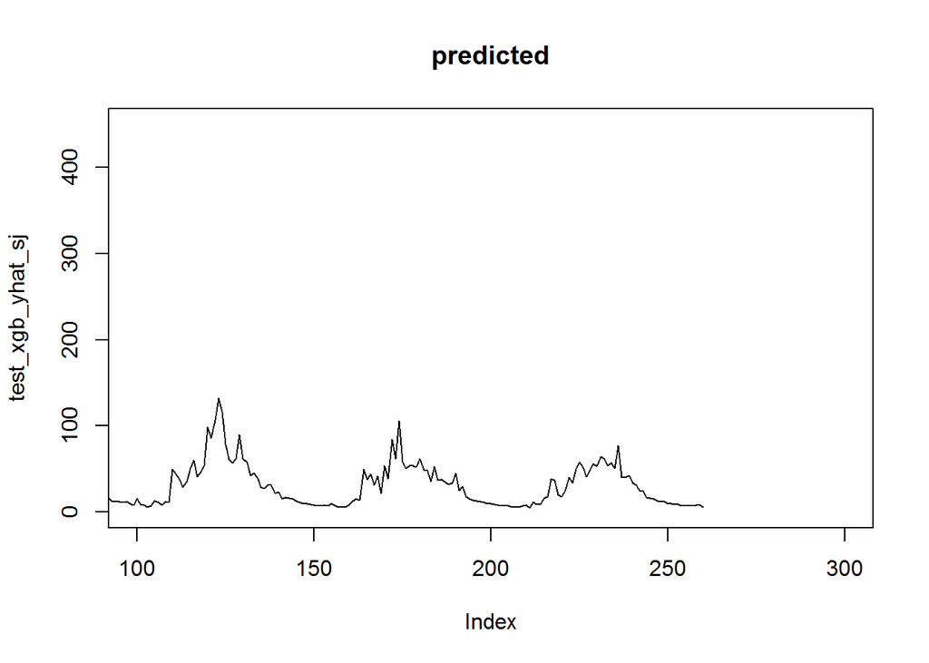

```r
plot(test_xgb_yhat_sj,type="l",ylim=c(0,450),xlim=c(100,300),main='predicted')
```

```r
fit_sj <- sma(test_xgb_yhat_sj)
```

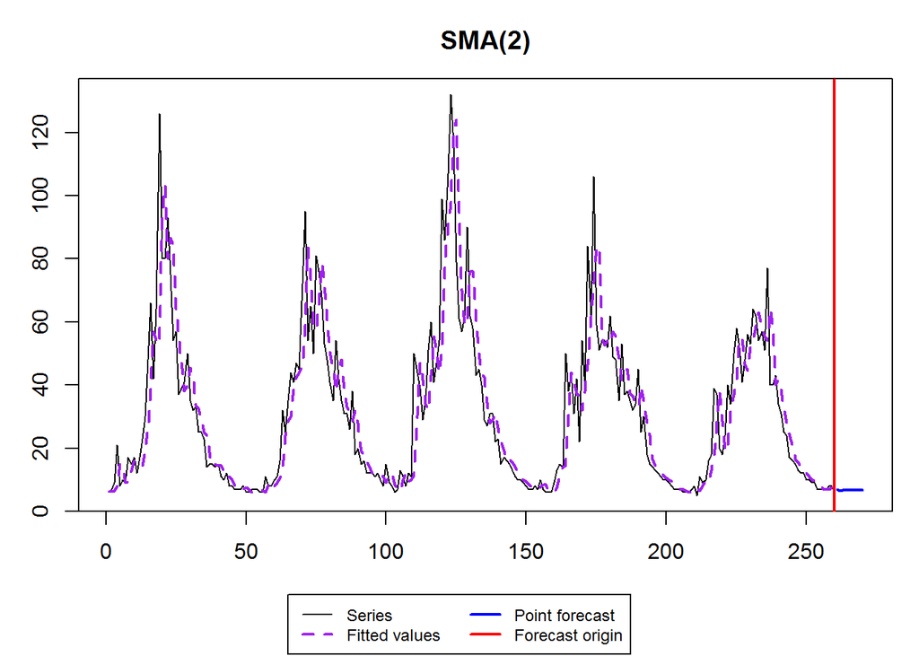

```r
fit_iq <- sma(test_xgb_yhat_iq)
```

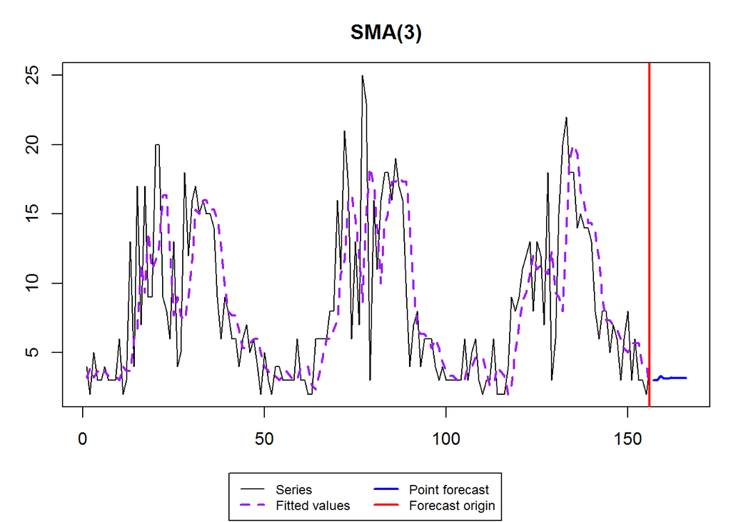

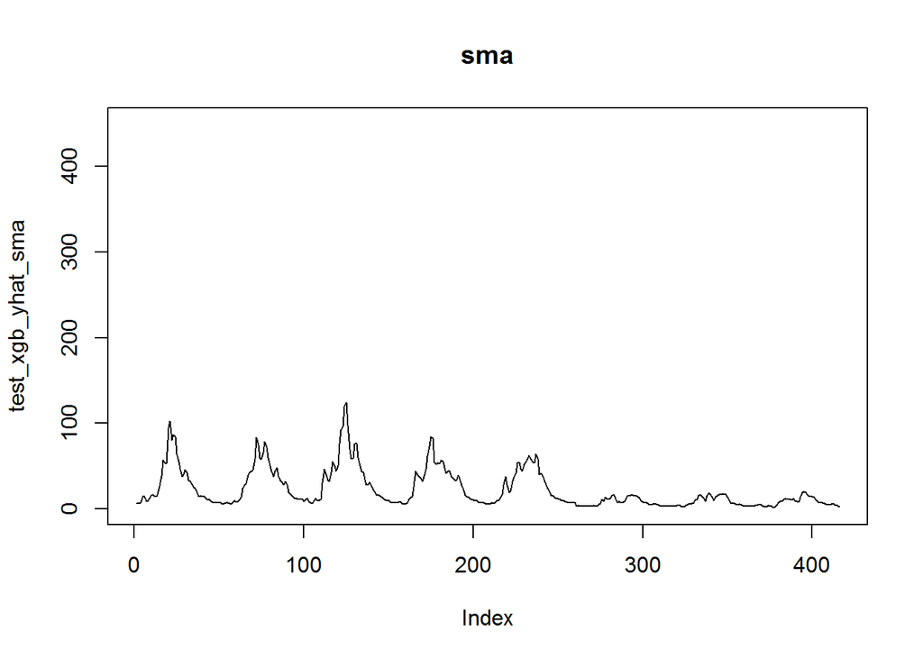

```r
test_xgb_yhat_sma <- c(as.numeric(fit_sj$fitted),as.numeric(fit_iq$fitted))
plot(test_xgb_yhat_sma,type="l",ylim=c(0,450),main="sma")
```

```r
submission <- read.csv(paste(path,'submission_format.csv',sep = ""),stringsAsFactors = F)
submission$total_cases <- round(test_xgb_yhat_sma)
head(submission)
```

```
##   city year weekofyear total_cases
## 1   sj 2008         18           6
## 2   sj 2008         19           6
## 3   sj 2008         20           6
## 4   sj 2008         21           8
## 5   sj 2008         22          15
## 6   sj 2008         23          14
```

```r
write.csv(submission,paste(path,'final_xgboost_2.csv',sep = ""),row.names=F,quote = F)
```

This model worked best. MAE: 25.3462